# ERA Livestock Data Exploration

Namita Joshi

n.joshi@cgiar.org

Peter Steward

p.steward@cgiar.org

Todd Rosenstock

t.rosenstock@cgiar.org

2024-12-15

This vignette will guide you through the livestock-related data available within the Evidence for Resilient Agriculture (ERA) dataset. The dataset serves as a critical resource for understanding agricultural resilience, specifically focusing on livestock systems and their adaptation to climate change.

We will cover the following:

*Methodology:*

*1. Search Terms Used*

*2. Screening Criteria Applied*

*3. Data Extraction Process*

*Exploration of Livestock Data in ERA:*

*1. Exploring geographic locations of studies available*

*2. Practices in changing diets*

*3. Understanding Diet compositions*

*4. Common outcomes reported*

# Methodology

## ERA Search Terms

Our initial search, conducted in 2014, queried the Web of Science and Scopus Databases for English language articles. Database queries consisted of key terms describing three components: technology, outcome, and geographic location. Given the myriad outcomes of interest, we constructed distinct search strings for each category: productivity, resilience, and mitigation outcomes, as well as a key term related to barriers to adoption.

Our methodology employed Boolean operators ‘OR’ and ‘AND’ to ensure the comprehensiveness of the search. This string for each technology category was run in both search engines for each of the outcome categories, ‘productivity,’ ‘resilience,’ ‘mitigation,’ and additionally for ‘barriers’.

Below in a snippet of the search terms used for the livestock extraction:

Search Terms for ERA Livestock

| Source | Subject | Query |
| --- | --- | --- |
| WoS | Livestock | (Livestock OR ‘mono gastric’ OR cattle OR sheep OR goats OR pigs OR poultry OR ruminant OR aquaculture OR fish*) AND (‘non-conventional feed’ OR ‘Forage productivity’ OR grass OR ‘pasture additive’ OR… |
| Scopus | Livestock | (Livestock OR ‘mono gastric’ OR cattle OR sheep OR goats OR pigs OR poultry OR ruminant OR aquaculture OR fish*) AND (‘non-conventional feed’ OR ‘Forage productivity’ OR grass OR ‘pasture additive’ OR… |

## Screening Criteria with PICOS Standards

This screening criteria is designed to systematically review papers focusing on livestock management and outcomes, applying both inclusion and exclusion criteria based on specific parameters. The framework ensures that the selected studies align with the objectives of the review, particularly within the context of livestock systems in Africa.

PICOS Framework The PICOS framework helps structure systematic reviews by defining key components: Population, Intervention, Comparison, Outcomes, and Study Design.

### Population (P):

The criteria focus on studies involving livestock, excluding fish unless explicitly directed (fish are separated into a distinct category). The geographic scope is limited to studies conducted in Africa.

### Intervention (I):

Eligible studies involve practices like: Pasture and grazing management. Feed experiments (including feed processing). Improved variety and herd density management. Manure management and related practices.

### Comparison (C):

Studies should ideally have a control group, except for papers reporting diet and intake where controls are not mandatory.

### Outcomes (O):

The review emphasizes studies reporting primary data on key outcomes: Reproductive performance, economics, yields, soil quality, biodiversity, emissions, and labour. Studies that report surveys or specific emission-related outcomes in controlled environments are included, but consultation with the team is recommended.

### Study Design (S):

Studies must focus on interventions and primary data collection. Lab experiments or greenhouse studies are excluded unless they focus on emission outcomes.

## Data Extraction Process

Data were extracted from tables, text, and figures. Figures were digitized using available software, such as Web Plot Digitizer (https://apps.automeris.io/wpd/).

The data was extracted using a macros enabled excel template:

https://cgiar-my.sharepoint.com/:x:/g/personal/p_steward_cgiar_org/EXUFiZJ-jopBoxHaC9MsBHUBHC-qVT66csvmjvxluJ_CWQ?e=bEG8kY

-Time periods

-Breed: Capturing information on whether the breed used in the experiment is improved or indegenous.

-Diets: This is broken into 3 tables; Ingredients fed to the animals, Nutritional content of each ingredient and the digestibility of those ingredients.

-Chemicals, Vaccines, Medicines that were given to the animals during the experiment

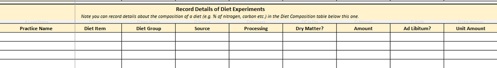

Image 1: Data extraction table for ingredients fed to the animals

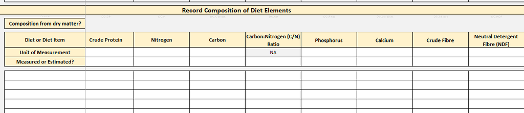

Image 2: Data extraction table for nutritional content of each ingredient or diets

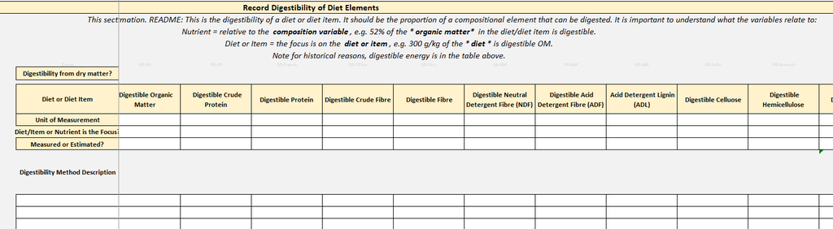

Image 3: Data extraction table for digestibility of the ingredients or diets

Data extractors went through an intensive 3 week training that included video tutorials and practical examples of extracting data with the livestock template.

Training materials can be found here: https://cgiar-my.sharepoint.com/:f:/g/personal/p_steward_cgiar_org/EmOgDnJmyX9KkD1s8rNqggsBlSDMvTavst0gd7VIwU3EMw?e=c1gHDf

### Livestock ontology

As part of the extraction process of the ERA Livestock, we created an ontology. The livestock ontology is a structured, hierarchical framework that defines and categorizes terms, concepts, and relationships related to livestock systems. It includes standardized definitions for livestock species, breeds, production systems, management practices, feed types, environmental factors, health indicators, and outcomes. By providing a shared vocabulary, livestock ontology facilitates consistent and comprehensive data representation across studies.

Link to the ontology: https://doi.org/10.7910/dvn/75e7hv

# Exploring the data

## Importing the data

### Link to github:

The code used to generate and compile the dataset from the excel files is in the ERAg R package using R 4.2.1 (R Development Team) and may be downloaded from GitHub https://github.com/EiA2030/ERAg.

### Downloading the data from the S3 bucket

The data can be downloading using the following code:

```r
#download   most    recent  version of  the data

#   Set up  connection  to  S3  bucket
  dl_dir<-"downloaded_data"
  s3<-s3fs::S3FileSystem$new(anonymous = T)
  era_s3<-"s3://digital-atlas/era"

  # List the files in the s3 bucket
  files<-s3$dir_ls(file.path(era_s3,"data"))
  # This is the most recent version of the datas3://digital-atlas/era/data/skinny_cow_2022-YYYY-MM-DD.RData (substitute most recent date into filepath)
  files<-tail(grep(".RData",grep("skinny_cow_2022",files,value=T),value=T),1)

  # Set a save location for the dataset (amend to something more suitable for your needs)
  save_path<-file.path(getwd(),dl_dir,basename(files))

  if(!file.exists(save_path)){
    s3$file_download(files,save_path,overwrite = T)
  }

  livestock_metadata<- miceadds::load.Rdata2(file=basename(save_path),path=dirname(save_path))
```

## Subsetting the ERA Compiled data

The Evidence for Resilient Agriculture (ERA) dataset provides a comprehensive analysis of the impacts of technology adoption on 87 key indicators spanning productivity, resilience, and climate change mitigation. This dataset integrates data from both agronomy and livestock studies, with a focus on creating control-versus-treatment comparisons to enable robust meta-analysis.

To extract insights specific to livestock, it is necessary to subset the dataset to isolate livestock-related studies, as follows (unhide the code):

```r
# Subset data
livestock_data<-ERA.Compiled[!is.na(Date)]
# Subset to fewer themes to simplify plot
livestock_data<-livestock_data[Product.Type %in% c("Animal")]
```

## Understanding the descriptions of major ERA concepts

Practice codes

```r
# Filter the data
filtered_data_prac <- ERAg::PracticeCodes %>%
  filter(Theme == "Animals")

# Display the filtered data in a scrollable table
DT::datatable(
  filtered_data_prac,
  options = list(
    scrollY = "400px",    # Set vertical scroll height
    scrollX = TRUE,       # Enable horizontal scrolling
    pageLength = 10,      # Display 10 rows per page
    fixedHeader = FALSE   # Disable fixed headers
  )
)
```

|  | Code | Theme | Theme.Code | Practice | Practice.Code | Subpractice | Subpractice.Code | Subpractice.S | Subpractice.Suffix | Definition | Notes | Linked.Tab | Linked.Col | Depreciated | Ref_Source | Ref_Name | Ref_Link | Ref_Match | Ref_Notes | Ref2_Source | Ref2_Name | Ref2_Link | Ref2_Match | Ref2_Notes |
| --- | --- | --- | --- | --- | --- | --- | --- | --- | --- | --- | --- | --- | --- | --- | --- | --- | --- | --- | --- | --- | --- | --- | --- | --- |
| 1 | d17.1 | Animals | Animals | Feed Addition | FA | Crop Fodders (Added) | FA+CF | Feed Crop (Add) | Add | Feeds added to animal diets that come from non-woody crops not usually grown for fodder, but for another purpose (e.g. consumption). These can be crop grain. field residues (for example maize stalks l… | Feeds are added compared to a control practice (basal diet) that does not contain items which would gain the same ERA classfication. Control diets are often hay ad libitum or hay ad libitum + maize st… | Animals.Out | A.Level.Name | False |  |  |  |  |  |  |  |  |  |  |
| 2 | d17.2 | Animals | Animals | Feed Addition | FA | Non Crop Fodders (Added) | FA+NC | Feed NonCrop (Add) | Add | Feeds added to animal diets that are non-woody crops grown primarily for fodder (e.g., alfafa or clover grown to feed to cattle) or non-woody plants harvested from non-cropped areas (e.g., forage gras… | Feeds are added compared to a control practice (basal diet) that does not contain items which would gain the same ERA classfication. Control diets are often hay ad libitum or hay ad libitum + maize st… | Animals.Out | A.Level.Name | False |  |  |  |  |  |  |  |  |  |  |
| 3 | d17.3 | Animals | Animals | Feed Addition | FA | Agroforestry Fodders (Added) | FA+AF | Feed AgFor (Add) | Add | Feeds added to animal diets that are from agroforestry shrub or tree fodders or other woody plants. | Feeds are added compared to a control practice (basal diet) that does not contain items which would gain the same ERA classfication. Control diets are often hay ad libitum or hay ad libitum + maize st… | Animals.Out | A.Level.Name | False |  |  |  |  |  |  |  |  |  |  |
| 4 | d17.4 | Animals | Animals | Feed Addition | FA | Animal Manures (Added) | FA+AM | Feed Manure (Add) | Add | Feeds added to animal diets that are animal manures. | Feeds are added compared to a control practice (basal diet) that does not contain items which would gain the same ERA classfication. Control diets are often hay ad libitum or hay ad libitum + maize st… | Animals.Out | A.Level.Name | False |  |  |  |  |  |  |  |  |  |  |
| 5 | d17.5 | Animals | Animals | Feed Addition | FA | Other Feed (Added) | FA+O | Feed Other (Add) | Add | Feeds added to animal diets that are non-plant or non-manure based materials. These typically include materials that are the by-product of animal processing (e.g., bone meal or fish meal). | Feeds are added compared to a control practice (basal diet) that does not contain items which would gain the same ERA classfication. Control diets are often hay ad libitum or hay ad libitum + maize st… | Animals.Out | A.Level.Name | False |  |  |  |  |  |  |  |  |  |  |
| 6 | d18.1 | Animals | Animals | Feed Substitution | FS | Crop Fodders (Substituted) | FS+CF | Feed Crop (Sub) | Sub | Components of a basal diet fully or partially substituted for residues from crops not primarily grown for fodder, but for another purpose (e.g. consumption). These can be field residues (for example m… | Substitutions are typically defined by the author. Usually they are looking to substitute a conventional (e.g. purchased diet) with cheaper or more sustainable alternatives. | Animals.Out | A.Level.Name | False |  |  |  |  |  |  |  |  |  |  |
| 7 | d18.2 | Animals | Animals | Feed Substitution | FS | Non Crop Fodders (Substituted) | FS+NC | Feed NonCrop (Sub) | Sub | Components of a basal diet fully or partially substituted for non-woody crops grown primarily for fodder (e.g., alfafa or clover grown to feed to cattle) or non-woody plants harvested from non-cropped… | Substitutions are typically defined by the author. Usually they are looking to substitute a conventional (e.g. purchased diet) with cheaper or more sustainable alternatives. | Animals.Out | A.Level.Name | False |  |  |  |  |  |  |  |  |  |  |
| 8 | d18.3 | Animals | Animals | Feed Substitution | FS | Agroforestry Fodders (Substituted) | FS+AF | Feed AgFor (Sub) | Sub | Components of a basal diet fully or partially substituted for agroforestry shrub or tree fodders (woody plants). | Substitutions are typically defined by the author. Usually they are looking to substitute a conventional (e.g. purchased diet) with cheaper or more sustainable alternatives. | Animals.Out | A.Level.Name | False |  |  |  |  |  |  |  |  |  |  |
| 9 | d18.4 | Animals | Animals | Feed Substitution | FS | Animal Manures (Substituted) | FS+AM | Feed Manure (Sub) | Sub | Components of a basal diet fully or partially substituted for animal manures. | Substitutions are typically defined by the author. Usually they are looking to substitute a conventional (e.g. purchased diet) with cheaper or more sustainable alternatives. | Animals.Out | A.Level.Name | False |  |  |  |  |  |  |  |  |  |  |
| 10 | d18.5 | Animals | Animals | Feed Substitution | FS | Other Feed (Substituted) | FS+O | Feed Byproducts (Sub) | Sub | Components of a basal diet fully or partially substituted with non-plant and non-manure based materials. These typically include materials for the by-product of animal processing (e.g., bone meal or f… | Substitutions are typically defined by the author. Usually they are looking to substitute a conventional (e.g. purchased diet) with cheaper or more sustainable alternatives. | Animals.Out | A.Level.Name | False |  |  |  |  |  |  |  |  |  |  |

[output cut: 19 more lines]

Outcome Codes

```r
DT::datatable(
  head(ERAg::OutcomeCodes),  # Display the first few rows of PracticeCodes
  options = list(
    scrollY = "400px",    # Set vertical scroll height
    scrollX = TRUE,       # Enable horizontal scrolling
    pageLength = 10,      # Display 10 rows per page
    fixedHeader = FALSE   # Disable fixed headers
  )
)
```

|  | Code | Pillar | Pillar.Code | Subpillar | Subpillar.Code | Indicator | Indicator.Code | Subindicator | Subindicator.Short | Subindicator.Code | Definition | Notes | Example units | Original.Outcome | Negative Values | Sign | TC.Ratio | Not.Perc | Depreciated |
| --- | --- | --- | --- | --- | --- | --- | --- | --- | --- | --- | --- | --- | --- | --- | --- | --- | --- | --- | --- |
| 1 | 101 | Productivity | Productivity | Yield | Yi | Product Yield | PY | Crop Yield | Crop Yield | CrY | Amount of crop plant product produced (e.g., grain or fruit yield) per unit area land. | When product and non-product components are not separated, for example measures of total, above-ground or below-ground crop biomass, the outcome sould be recorded using the Biomass Yield Outcome. Non-… | t/ha;kg/ha |  | N | p | N | Y | False |
| 2 | 101.1 | Productivity | Productivity | Yield | Yi | Product Yield | PY | Biomass Yield | Biomass Yield | BiY | Plant biomass yield. This can be used to describe pasture biomass yields or when total, above ground, or below ground biomass yields are given for crops that are usually split into product and non-pro… |  | t/ha;kg/ha |  | N | p | N | Y | False |
| 3 | 101.2 | Productivity | Productivity | Yield | Yi | Product Yield | PY | Extraction Yield | Extraction Yield | ExY | Extraction yield of oil from oil seeds or similar. For example 300kg oil extracted from 1000kg oil seeds = 0.3 or 30% oil yield per kg oil seeds. | This outcome should be a percentage or ratio. | Unitless ratio; % |  | N | p | N | N | False |
| 4 | 103 | Productivity | Productivity | Yield | Yi | Product Yield | PY | Land Equivalent Ratio | LER | LER | The land equivalent ratio describes the relative land area required under sole cropping (monoculture) to produce the same yield as under intercropping (polyculture). | We do not accept LER for practice A vs practice B (e.g. mulch vs no-mulch as this yield A/yield B, which we calculated as the response ratio). | Unitless ratio |  | N | p | Y | Y | False |
| 5 | 118 | Productivity | Productivity | Yield | Yi | Product Yield | PY | Weight Gain | Weight Gain | WG | Change in animal weight relative to a baseline (usually weight at the start of an experiment) over a specified time period. | Please try to standardise to g per animal per day (g/individual/day). Default unit is unit/individual (e.g kg/cow) unless otherwise stated. Values for this outcome can be negative (the animal loses we… | g/individual/day SGR (Specific Growth Rate) |  | Y | p | N | Not Sure | False |
| 6 | 119.1 | Productivity | Productivity | Yield | Yi | Product Yield | PY | Meat Yield | Meat Yield | MeY | The total weight of the animal or meat parts of it. | This should not be an increase from a baseline weight (this is recorded under the Weight Gain outcome). Please try and standardise units kg/individual, you may specify the type of meat or weight measu… | kg/individual |  | N | p | N | Y | False |

Products

```r
# Filter the data
filtered_data_eu <- ERAg::EUCodes %>%
  filter(Product.Type == "Animal")

# Display the filtered data in a scrollable table
DT::datatable(
  filtered_data_eu,
  options = list(
    scrollY = "400px",    # Set vertical scroll height
    scrollX = TRUE,       # Enable horizontal scrolling
    pageLength = 10,      # Display 10 rows per page
    fixedHeader = FALSE   # Disable fixed headers
  )
)
```

|  | EU | Product.Type | Product.Type.Code | Product.Subtype | Product.Subtype.Code | Product.Subtype.Code.Check | Product | Product.Simple | Product.Simple.Code | Product.Code.Check | Component | Latin.Name | Notes | Nfix | Tree | Mulched | Incorp | Unknown.Fate | ECOCROP.Name | ECOCROP.Notes | ICC_Code_1.1 | ICC_CropName | Livestock_Group | Livestock_Class | Livestock_Descriptor | CPC_Code_2.1 | WFO_Code | UN_Comtrade_Code_1 | UN_Comtrade_Description_1 | … |
| --- | --- | --- | --- | --- | --- | --- | --- | --- | --- | --- | --- | --- | --- | --- | --- | --- | --- | --- | --- | --- | --- | --- | --- | --- | --- | --- | --- | --- | --- | --- |
| 1 | a10 | Animal | Animal | Eggs (Stored) | Egg | True | Stored Eggs (Chicken) | Eggs | Egg | True |  |  | Only to be used for storage papers. |  |  |  |  |  |  |  |  |  | 14 | 146 | raising of poultry-production of eggs | no match |  | 40721 | birds' eggs, in shell; fresh, not for incubation, of fowls of the species Gallus domesticus (domestic hens) | … |
| 2 | a11 | Animal | Animal | Eggs (Stored) | Egg | True | Stored Eggs (Other) | Eggs | Egg | True |  |  | Only to be used for storage papers. |  |  |  |  |  |  |  |  |  | 14 | 146 | raising of poultry-production of eggs | no match |  | 407 | birds' eggs, in shell; fresh, preserved or cooked | … |
| 3 | a5 | Animal | Animal | Bovine | Bo | True | Buffalo | Buffalo | Buf | True | Meat | Bubalus bubalis |  |  |  |  |  |  |  |  |  |  | 1 | 12 | buffaloes | 2112 |  | 201 | meat of bovine animals; fresh or chilled | … |
| 4 | a6 | Animal | Animal | Camelid | Cam | True | Camel (Meat) | Camel | Cam | True | Meat | Camelus dromedarius |  |  |  |  |  |  |  |  |  |  | 5 | 51 | camels | 2121 |  | 20860 | meat and edible meat offal; of camels and other camelids (Camelidae), fresh, chilled or frozen | … |
| 5 | a6.1 | Animal | Animal | Camelid | Cam | True | Camel (Milk) | Camel | Cam | True | Milk | Camelus dromedarius |  |  |  |  |  |  |  |  |  |  | 5 | 51 | camels | 2121 |  | 10613 | mammals; live, camels and other camelids (Camelidae) | … |
| 6 | a8 | Animal | Animal | Bovine | Bo | True | Cattle (Meat) | Cattle | Cat | True | Meat |  |  |  |  |  |  |  |  |  |  |  | 1 | 11 | cattle | 2111 |  | 201 | meat of bovine animals; fresh or chilled | … |
| 7 | a8.1 | Animal | Animal | Bovine | Bo | True | Cattle (Milk) | Cattle | Cat | True | Milk |  |  |  |  |  |  |  |  |  |  |  | 1 | 11 | cattle | 2111 |  | 401 | milk and cream; not concentrated, not containing added sugar or other sweetening matter | … |
| 8 | a13 | Animal | Animal | Caprine | Cap | True | Goat (Meat) | Goat | Goa | True | Meat | Capra aegagrus hircus |  |  |  |  |  |  |  |  |  |  | 2 | 22 | goats | 2123 |  | 20450 | meat; of goats, fresh, chilled or frozen | … |
| 9 | a13.1 | Animal | Animal | Caprine | Cap | True | Goat (Milk) | Goat | Goa | True | Milk | Capra aegagrus hircus |  |  |  |  |  |  |  |  |  |  | 2 | 22 | goats | 2123 |  | 10420 | Goats; live | … |
| 10 | a16 | Animal | Animal | Porcine | Por | True | Pig | Pigs | Pig | True | Meat | Sus scrofa domesticus |  |  |  |  |  |  |  |  |  |  | 3 | 3 | swine/ pigs | 2140 |  | 203 | meat of swine; fresh, chilled or frozen | … |

[output cut: 24 more lines]

## Exploring geographic locations of studies available

This dataset represents spatial information about livestock-related research papers across various countries in Africa. Each point on the map corresponds to a geographic location associated with a research paper, categorized by livestock type (e.g., cattle, goat, sheep, etc.). The dataset includes:

Country: The country where the research is associated. Latitude and Longitude: Coordinates representing the location of the research. Product.Simple: The type of livestock being studied. Counts: The number of papers associated with each location (aggregated for the map). This data provides an overview of the geographic distribution and focus of livestock research, enabling users to explore patterns and trends by livestock type and region.

```r
# Create a leaflet map with interactive filtering
# Subset the livestock data
site_data <- livestock_data %>%
  dplyr::select(Product.Simple, Country, Latitude, Longitude) %>%
  distinct() %>%
  mutate(
    Longitude = as.numeric(Longitude),
    Latitude = as.numeric(Latitude)
  ) %>%
  filter(!is.na(Longitude) & !is.na(Latitude))  # Remove rows with missing coordinates

# Count the number of records per country
livestock_counts <- site_data %>%
  group_by(Country,Product.Simple) %>%
  summarise(N_Livestock = n())

# Prepare the world map with only African countries
world <- ne_countries(scale = "medium", returnclass = "sf") %>%
  filter(continent == "Africa") %>%  # Filter for African continent only
  mutate(admin = if_else(admin == "United Republic of Tanzania", "Tanzania", admin))

# Ensure the CRS is consistent (EPSG:4326)
world <- st_transform(world, crs = 4326)

# Convert site data to spatial format (only for African countries)
site_data_filtered <- site_data %>%
  filter(Country %in% world$admin) %>%  # Filter site data for African countries
  st_as_sf(coords = c("Longitude", "Latitude"), crs = 4326, remove = FALSE)

# Join livestock counts with African country geometries for mapping
countries_studies <- world %>%
  dplyr::select(admin, geometry) %>%
  rename(Country = admin) %>%
  left_join(livestock_counts, by = "Country")
```

```r
if (!requireNamespace("leaflet", quietly = TRUE)) {
  install.packages("leaflet")
}
if (!requireNamespace("crosstalk", quietly = TRUE)) {
  install.packages("crosstalk")
}
if (!requireNamespace("htmltools", quietly = TRUE)) {
  install.packages("htmltools")
}
library(leaflet)
library(crosstalk)
library(htmltools)
library(dplyr)

# Prepare the data
site_data <- site_data %>%
  mutate(
    Longitude = as.numeric(Longitude),
    Latitude = as.numeric(Latitude)
  ) %>%
  filter(!is.na(Longitude) & !is.na(Latitude))  # Remove rows with missing coordinates

# Create a shared data object for crosstalk
shared_site_data <- SharedData$new(site_data, key = ~Product.Simple, group = "LivestockType")

# Create an interactive map linked to the shared data
map <- leaflet(shared_site_data) %>%
  addProviderTiles(providers$CartoDB.Positron) %>%  # Add a base map
  addCircles(
    lng = ~Longitude,
    lat = ~Latitude,
    color = "#3333ff",
    radius = 30000,  # Adjust the radius for better visualization
    popup = ~paste0(
      "<b>Country:</b> ", Country, "<br>",
      "<b>Livestock Type:</b> ", Product.Simple
    ),
    opacity = 0.8,
    fillOpacity = 0.5
  ) %>%
  addLegend(
    position = "bottomright",
    colors = "#3333ff",
    labels = "Livestock Study Sites",
    title = "Legend"
  )

# Create a dropdown filter and bind it to the map
htmltools::browsable(
  tagList(
    tags$h3("Livestock Type Filter"),  # Add a title for the filter
    bscols(
      widths = c(3, 9),  # Adjust the layout: 3 for the filter, 9 for the map
      filter_select(
        id = "livestock_filter",
        label = "Select Livestock Type",
        shared_site_data,
        ~Product.Simple,  # Column to filter
        multiple = FALSE  # Single selection
      ),
      map
    )
  )
)
```

### Livestock Type Filter

Select Livestock Type

[interactive chart not shown]

## Animals reported within papers

The treemap represents the distribution of livestock categories reported within research papers that were extracted in ERA. Each rectangle corresponds to a livestock category, and its size is proportional to the number of papers reporting on that category. Here’s an analysis of the data shown:

Dominant Categories:

Sheep: The largest rectangle (120 papers) indicates that sheep are the most frequently reported livestock category in the dataset. This could reflect their significant role in agricultural research and practices.

Moderately Represented Categories:

Cattle (96 papers) and Fish (71 papers) are also prominent, reflecting their widespread use in agricultural systems, both for food production and other economic activities.

```r
# UI
ui <- fluidPage(
  plotlyOutput("treemapPlot", height = "400px")  # Set plot height
)

# Server
server <- function(input, output, session) {
  output$treemapPlot <- renderPlotly({
    # Prepare data for the treemap
    products <- livestock_data %>%
      distinct(Product.Simple, Code) %>%  # Keep only unique combinations
      group_by(Product.Simple) %>%
      summarise(Row_Count = n(), .groups = "drop")  # Count occurrences per category

    # Create the Plotly treemap
    plot_ly(
      type = "treemap",
      labels = products$Product.Simple,
      parents = NA,  # No hierarchical structure in this case
      values = products$Row_Count,
      textinfo = "label+value",  # Display labels and values
      marker = list(colorscale = "Viridis")  # Apply a color scale
    )
  })
}

# Run the Shiny app
shinyApp(ui, server)
```

Shiny applications not supported in static R Markdown documents

## Outcomes reported

Outcome measures, units, and products were extracted as reported. Outcome codes differentiated plant parts (grain vs stover) and products from the same species (milk versus meat). Oftentimes authors discussed many treatments but only reported a few. The ways in which the outcomes were reported in the papers, by year or aggregation across practices, dictated which data were extracted and how treatments were coded. Experimental Units (EU) described the species or product that were measured (e.g., maize grain).

```r
# Define the UI
# Define the UI
ui <- fluidPage(
  mainPanel(
    plotlyOutput("outcomesPlot", width = "100%", height = "400px")  # Adjust plot dimensions
  )
)

# Define the server logic
server <- function(input, output) {
  output$outcomesPlot <- renderPlotly({
    # Aggregate data by pillar and indicator
    DATA_OUTCOMES <- livestock_data %>%
      group_by(Out.Pillar, Out.Ind) %>%
      summarise(N_Livestock = n_distinct(Code), .groups = "drop") %>%
      rename(Pillar = Out.Pillar, Indicator = Out.Ind)

    # Sort indicators within each pillar for better organization
    DATA_OUTCOMES <- DATA_OUTCOMES %>%
      arrange(Pillar, Indicator) %>%
      mutate(
        Indicator = factor(Indicator, levels = unique(Indicator)),
        Pillar = factor(Pillar, levels = c("Productivity", "Resilience", "Mitigation"))
      )

    # Define hover information for specific indicators
    hover_info <- tibble(
      Indicator = c("Product Yield", "Income", "Economic Performance","Costs", "Soil Quality","Efficiency"),
      HoverDetails = c("Meat yield; Egg yield; Milk yield; Reproductive yield; Weight gain","Gross return; Gross margin; Net return","Benefit Cost Ratios","Labour cost; Total cost; Fixed cost; Variable cost","Soil Erosion; Soil Nitrogen; Soil Organic Carbon","Feed Conversion Ratios; Protein Conversion Ratios; Nitrogen Apparent Efficiency")
    )

    # Add hover text to the data
    DATA_OUTCOMES <- DATA_OUTCOMES %>%
      left_join(hover_info, by = "Indicator") %>%  # Join hover info
      mutate(
        HoverText = ifelse(
          !is.na(HoverDetails),
          paste0("<b>", Indicator, "</b><br>", HoverDetails, "<br><i>Count:</i> ", N_Livestock),
          paste0("<b>", Indicator, "</b><br><i>Count:</i> ", N_Livestock)
        )
      )

    # Define custom colors for each pillar
    pillar_colors <- c(
      "Productivity" = "#FFCC66",
      "Resilience" = "#990000",
      "Mitigation" = "#8B4513"
    )

    # Create the faceted bar plot with ggplot
    p <- ggplot(DATA_OUTCOMES, aes(
      x = Indicator, y = N_Livestock, fill = Pillar, text = HoverText
    )) +
      geom_col(width = 0.8) +  # Vertical bars
      labs(
        y = "Number of Papers",
        x = "Outcome Indicator"
      ) +
      scale_fill_manual(values = pillar_colors, na.value = "gray70") +
      scale_y_continuous(limits = c(0, max(DATA_OUTCOMES$N_Livestock) + 50), expand = c(0, 0)) +
      facet_wrap(~Pillar, scales = "free_x", nrow = 1) +
      theme_minimal() +
      theme(
        axis.text.x = element_text(size = 10, angle = 45, hjust = 1),  # Rotate x-axis labels
        axis.text.y = element_text(size = 10),  # Adjust y-axis labels
        axis.title.x = element_text(size = 12, face = "bold", margin = margin(t = 10)),  # Add margin
        axis.title.y = element_text(size = 12, face = "bold"),  # Y-axis title styling
        legend.position = "none",  # Remove legend
        panel.grid.major = element_blank(),
        panel.grid.minor = element_blank(),
        strip.text = element_text(size = 12, face = "bold"),  # Facet strip labels styling
        plot.margin = margin(10, 10, 10, 10)  # Reduced margins
      )

    # Convert ggplot to a plotly object
    ggplotly(p, tooltip = "text")  # Use hover text for tooltips
  })
}

# Run the app
shinyApp(ui = ui, server = server)
```

Shiny applications not supported in static R Markdown documents

# Use Case: Understanding the impact of tree fodders on feed intake and weight gain

The objective of this analysis is to systematically analyze and explore the impact of livestock feeding practices, particularly tree fodder addition and substitution, on key outcomes (e.g., weight gain, feed intake). To achieve this, we will follow these steps:

**1. Loading Required Libraries and Functions as shown earlier in this vignette. This will require the most recent version of the data, which will come from the S3 bucket**

**2.Data Cleaning and Filtering**

*2.1 Sub-setting the data to specific livestock (e.g., cattle, sheep, goats) and practices involving tree fodder addition or substitution.*

*2.2 Harmonizing Units: Converts weight units (e.g., kg to g per individual per day) for consistent analysis.*

*2.3 Exploring Practices and Outcomes: Summarizes data availability at the sub-practice and practice levels*

**3. Linking Observations to Metadata: The script links experimental data with metadata to understand: The specific diet fed to animals, nutritional composition and digestibility of the diet, Key fields in the metadata that describe treatments and practices.**

**4. Plotting simple figures**

*4.1 Plotting weight gain distribution with outliers*

*4.2 Plotting weight gain distribution without outliers*

PLEASE UNHIDE THE CODES TO VIEW. You can use these to tailor to your own needs

## 1. Loading and saving the data

This section retrieves the most recent version of the livestock dataset from an S3 bucket. It lists the available files, downloads the required .RData file, and loads it into R using miceadds::load.Rdata2. The objective is to prepare the dataset (livestock_metadata) for analysis.

```r
# First we need to get the detailed dataset containing the management information that relates to the experiment, this is in the Atlas S3 Bucket

  dl_dir<-"downloaded_data"
  s3<-s3fs::S3FileSystem$new(anonymous = T)
  era_s3<-"s3://digital-atlas/era"

  # List the files in the s3 bucket
  files<-s3$dir_ls(file.path(era_s3,"data"))
  # This is the most recent version of the datas3://digital-atlas/era/data/skinny_cow_2022-YYYY-MM-DD.RData (substitute most recent date into filepath)
  files<-tail(grep(".RData",grep("skinny_cow_2022",files,value=T),value=T),1)

  # Set a save location for the dataset (amend to something more suitable for your needs)
  save_path<-file.path(getwd(),dl_dir,basename(files))

  if(!file.exists(save_path)){
    s3$file_download(files,save_path,overwrite = T)
  }

  livestock_metadata<- miceadds::load.Rdata2(file=basename(save_path),path=dirname(save_path))
```

## 2. Data cleaning and subsetting

### 2.1 Subsetting the data

```r
focal_pracs<-PracticeCodes[Practice %in% c("Feed Addition","Feed Substitution")
                            & grepl("Agrofor",Subpractice),Code]

data<-ERA.Compiled[grepl(paste(focal_pracs,collapse = "|"),plist)]

  # 1.2) Subset to cattle and small ruminants #####
  focal_prods<-c("Cattle","Goat","Sheep")

  data<-data[Product.Simple %in% focal_prods]

  # 1.3) Subset to outcomes of interest  #####
  focal_out<-c("Meat Yield","Weight Gain","Milk Yield")

  data<-data[Out.SubInd %in% focal_out]


# List the files in the s3 bucket
files<-s3$dir_ls(file.path(era_s3,"data"))
# This should be the most recent version of the data era_compiled-v1.0_2018-v1.1_2020-skinny_cow_2022_YYYY_MM_DD.parquet
files<-tail(grep("parquet",grep("era_compiled",files,value=T),value=T),1)

# Set a save location for the dataset (amend to something more suitable for your needs)
save_path<-file.path(getwd(),dl_dir,basename(files))

if(!file.exists(save_path)){
  s3$file_download(files,save_path,overwrite = T)
}

ERA.Compiled_new<-arrow::read_parquet(save_path)
data_new<-ERA.Compiled_new[Version=="skinny_cow_2022" & grepl(paste(focal_pracs,collapse = "|"),plist)]

# Remove confounding subpractices
data_new<-data_new[!grepl("Concentrates|Feed Crop|Breed|Feed NonCrop",SubPrName)]

# The newer dataset on the s3 should be superior to old dataset so let's use it
data<-data_new

# Remove mechanical processing (this is just going to be chopping tree forages, probably not of interest)
  data[,SubPrName:=gsub("-Feed Mech Process|-Grazing Cut & Carry","",SubPrName)]

# Looking at any practices than involve tree fodder addition or substitution
  data<-data[,tree_fodder_add:=F][grepl("Feed AgFor (Add)",SubPrName,fixed=T),tree_fodder_add:=T]
  data<-data[,tree_fodder_sub:=F][grepl("Feed AgFor (Sub)",SubPrName,fixed=T),tree_fodder_sub:=T]
```

### 2.2 Harmonizing units

Unit harmonization is essential when studying livestock papers to ensure consistency and comparability across diverse datasets. In livestock research, data on outcomes like feed intake or weight gain are often reported in various units, such as kilograms (kg), grams per individual per day (g/individual/day), or other measurement standards. Without harmonization, direct comparisons or meta-analyses become challenging, as the variability in units can introduce bias or inaccuracies in the interpretation of results. By standardizing units, such as converting weight data from kg to g/day or normalizing by the duration of the study, researchers can create a uniform dataset. This allows for meaningful cross-study comparisons, improved statistical analysis, and clearer insights into the impacts of specific practices on livestock productivity, such as weight gain or feed efficiency.

```r
# 3.2) Harmonize units #####
  data[Units=="kg" & !is.na(Duration),c("MeanT","MeanC","Units"):=.(round(1000*MeanT/(365*Duration),2),round(1000*MeanC/(365*Duration),2),"g/individual/day")
              ][Units=="kg/individual/day",c("MeanT","MeanC","Units"):=.(round(1000*MeanT,2),round(1000*MeanC,2),"g/individual/day")]
```

### 2.3 Exploring the subsetted data

After subsetting the data, you can explore the number of remaining papers that are within your research focus. The following table The table provides insights into the data coverage for different livestock practices, products, and outcomes. For example, “Feed Addition” applied to “Goat” for “Weight Gain” is reported in 15 studies with 48 observations from 6 countries. This information can help identify well-studied areas and data gaps in livestock research

|  | PrName | Product.Simple | Out.SubInd | no_studies | no_observations | no_countries |
| --- | --- | --- | --- | --- | --- | --- |
| 1 | Feed Addition | Goat | Weight Gain | 15 | 48 | 6 |
| 2 | Feed Substitution | Sheep | Weight Gain | 13 | 59 | 4 |
| 3 | Feed Substitution | Goat | Weight Gain | 13 | 49 | 8 |
| 4 | Feed Addition | Sheep | Weight Gain | 12 | 50 | 4 |
| 5 | Feed Addition | Goat | Meat Yield | 10 | 69 | 6 |
| 6 | Feed Substitution | Goat | Meat Yield | 10 | 27 | 6 |
| 7 | Feed Substitution | Sheep | Meat Yield | 9 | 42 | 4 |
| 8 | Feed Addition | Cattle | Weight Gain | 7 | 23 | 4 |
| 9 | Feed Addition | Sheep | Meat Yield | 7 | 17 | 2 |
| 10 | Feed Substitution | Goat | Nitrogen (Apparent Efficiency Animals Feed) | 6 | 20 | 3 |

[output cut: 100 more lines]

We can choose to explore the data in future detail. The table below shows the studies that looked at the impact of adding tree fodders to diets of cattle goat and sheep.

|  | Product.Simple | Out.SubInd | no_studies | no_observations | no_countries |
| --- | --- | --- | --- | --- | --- |
| 1 | Goat | Weight Gain | 17 | 54 | 7 |
| 2 | Sheep | Weight Gain | 13 | 53 | 4 |
| 3 | Goat | Meat Yield | 11 | 72 | 6 |
| 4 | Cattle | Weight Gain | 10 | 35 | 5 |
| 5 | Sheep | Meat Yield | 8 | 29 | 2 |
| 6 | Cattle | Meat Yield | 5 | 15 | 3 |
| 7 | Cattle | Milk Yield | 5 | 8 | 3 |
| 8 | Sheep | Feed Conversion Ratio (Out In) | 4 | 8 | 1 |
| 9 | Sheep | Nitrogen (Apparent Efficiency Animals Feed) | 3 | 13 | 2 |
| 10 | Goat | Feed Conversion Ratio (Out In) | 2 | 6 | 1 |

[output cut: 25 more lines]

|  | Product.Simple | Out.SubInd | no_studies | no_observations | no_countries |
| --- | --- | --- | --- | --- | --- |
| 1 | Sheep | Weight Gain | 16 | 70 | 6 |
| 2 | Goat | Weight Gain | 15 | 55 | 8 |
| 3 | Sheep | Meat Yield | 12 | 74 | 6 |
| 4 | Goat | Meat Yield | 12 | 33 | 7 |
| 5 | Chicken | Weight Gain | 8 | 32 | 6 |
| 6 | Chicken | Feed Conversion Ratio (In Out) | 6 | 26 | 5 |
| 7 | Goat | Nitrogen (Apparent Efficiency Animals Feed) | 6 | 20 | 3 |
| 8 | Fish | Weight Gain | 5 | 21 | 3 |
| 9 | Fish | Feed Conversion Ratio (In Out) | 5 | 21 | 3 |
| 10 | Cattle | Milk Yield | 5 | 14 | 3 |

[output cut: 35 more lines]

## 3. Linking observations to the metadata

As mentioned in the methods section, each table in the extraction excel template creates a seperate table in the data structure. Therefore, when using the metadata (which are the original seperate tables) we need to merge the tables that we are interested in.

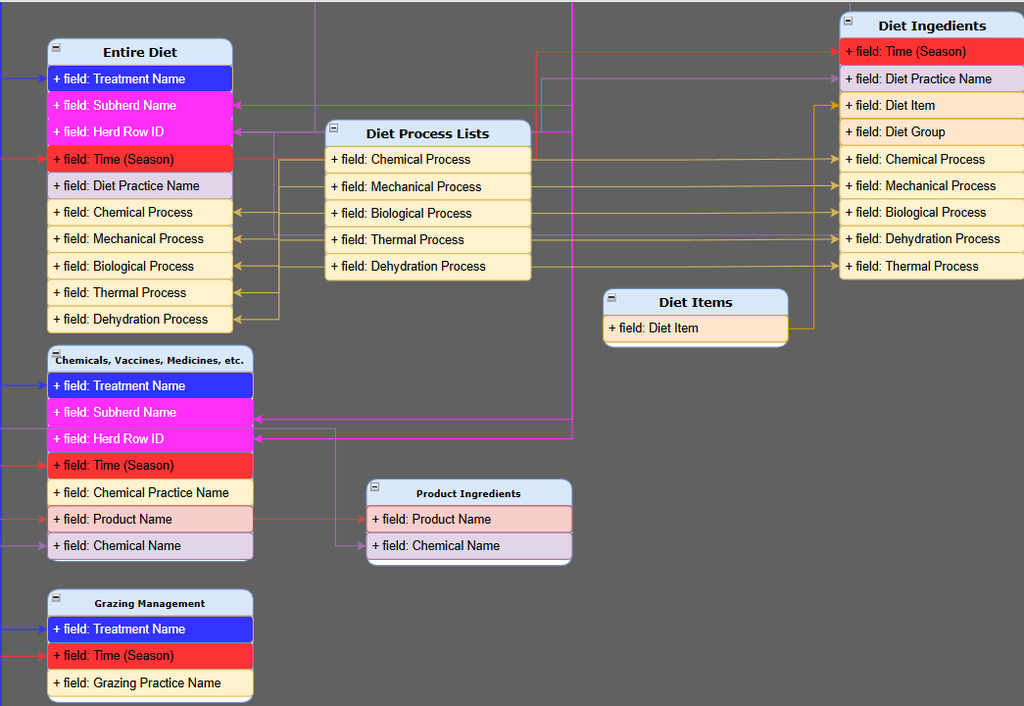

Image 4: Data structure of diets

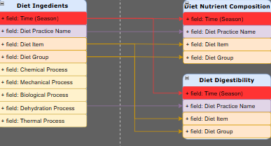

Image 5: Data structure of diet ingredients

Below are the individual tables for diets, nutrition and digestibility. We will then explore how to merge information from the different tables. To understand what the field are in each table download the follow excel sheet and navigate to the era_fields tab https://github.com/peetmate/era_codes/raw/main/era_master_sheet.xlsx”

```r
  # 4.2) Explore  metadata #####
  # This table is a high level description of the diet
  diet_summary<-livestock_metadata$Animals.Out

    diet_ingredients<-livestock_metadata$Animals.Diet
  head(diet_ingredients)
```

```
#>    D.Item.AOM  D.ItemxProcess_low A.Level.Name               D.Type
#>        <char>              <char>       <char>               <char>
#> 1: AOM_001911                 hay         Base   Herbaceous Fodders
#> 2: AOM_000604    groundnut haulms     150g/day       Crop Byproduct
#> 3: AOM_000604    groundnut haulms     300g/day       Crop Byproduct
#> 4: AOM_000604    groundnut haulms     450g/day       Crop Byproduct
#> 5: AOM_001901 atriplex nummularia         Base Agroforestry Fodders
#> 6: AOM_000647        barley grain           T2         Crop Product
#>                   D.Item D.Item.Group D.Source D.Process DC.Is.Dry D.Amount
#>                   <char>       <char>   <char>    <list>    <char>    <num>
#> 1: Unspecified Grass Hay         <NA>     <NA>        NA       Yes       NA
#> 2:       Groundnut Haulm         <NA>     <NA>        NA       Yes      150
#> 3:       Groundnut Haulm         <NA>     <NA>        NA       Yes      300
#> 4:       Groundnut Haulm         <NA>     <NA>        NA       Yes      450
#> 5:   Atriplex nummularia         <NA>     <NA>        NA      <NA>       NA
```

[output cut: 57 more lines]

```r
  diet_nutrition<-livestock_metadata$Animals.Diet.Comp
  head(diet_nutrition)
```

```
#>      B.Code                    D.Item DC.Unit.Is.Dry is_group is_entire_diet
#>      <char>                    <char>         <char>   <lgcl>         <lgcl>
#> 1:   NN0005                       0 M            Yes    FALSE           TRUE
#> 2: HK0066.1                     0 MSK    Unspecified    FALSE           TRUE
#> 3: HK0066.2                     0 MSK    Unspecified    FALSE           TRUE
#> 4:   HK0330        0 g/kg A. tortilis            Yes    FALSE           TRUE
#> 5:   NJ0003               0 g/kg CBLE            Yes    FALSE           TRUE
#> 6:   HK0326 0 g/kg potato hash silage            Yes    FALSE           TRUE
#>    D.Item.Root.Comp.Proc_Major D.Item.Root.Other.Comp.Proc_All D.Item.AOM
#>                         <char>                          <char>     <char>
#> 1:                        <NA>                            <NA>       <NA>
#> 2:                        <NA>                            <NA>       <NA>
#> 3:                        <NA>                            <NA>       <NA>
#> 4:                        <NA>                            <NA>       <NA>
#> 5:                        <NA>                            <NA>       <NA>
#> 6:                        <NA>                            <NA>       <NA>
#>    DC.Value DC.Unit   DC.Method DC.Variable                D.Item.raw
#>       <num>  <char>      <char>      <char>                    <char>
#> 1:   876.00    g/kg    Measured          DM                       0 M
#> 2:   921.00    g/kg    Measured          DM                     0 MSK
#> 3:   881.00    g/kg    Measured          DM                     0 MSK
#> 4:   867.00    g/kg    Measured          DM        0 g/kg A. tortilis
#> 5:    90.84       % Unspecified          DM               0 g/kg CBLE
#> 6:   886.00    g/kg    Measured          DM 0 g/kg potato hash silage
```

```r
  diet_digestibility<-livestock_metadata$Animals.Diet.Digest
  head(diet_digestibility)
```

```
#>    B.Code            D.Item DD.Unit.Is.Dry is_group is_entire_diet
#>    <char>            <char>         <char>   <lgcl>         <lgcl>
#> 1: AN0057             0 PPL            Yes    FALSE           TRUE
#> 2: LM0104  0% A. sieberiana            Yes    FALSE           TRUE
#> 3: HK0033 0% Brewer's Grain    Unspecified    FALSE           TRUE
#> 4: EO0046            0% CFL            Yes    FALSE           TRUE
#> 5: HK0108  0% Leucaena Diet    Unspecified    FALSE           TRUE
#> 6: HK0008  0% Leucaena Goat    Unspecified    FALSE           TRUE
#>    D.Item.Root.Comp.Proc_Major D.Item.Root.Other.Comp.Proc_All D.Item.AOM
#>                         <char>                          <char>     <char>
#> 1:                        <NA>                            <NA>       <NA>
#> 2:                        <NA>                            <NA>       <NA>
#> 3:                        <NA>                            <NA>       <NA>
#> 4:                        <NA>                            <NA>       <NA>
#> 5:                        <NA>                            <NA>       <NA>
```

[output cut: 17 more lines]

#### Diet ingredients table

```r
  # Display the summary table   of  diets
DT::datatable(
  diet_ingredients,
  options = list(
    scrollY = "400px",  # Set vertical scroll height
    scrollX = TRUE,     # Enable horizontal scrolling
    pageLength = 20,    # Initial number of rows displayed
    fixedHeader = FALSE  # Keep column headers fixed while scrolling
  )
)
```

|  | D.Item.AOM | D.ItemxProcess_low | A.Level.Name | D.Type | D.Item | D.Item.Group | D.Source | D.Process | DC.Is.Dry | D.Amount | D.Ad.lib | D.Unit.Amount | D.Unit.Time | D.Unit.Animals | D.Day.Start | D.Day.End | B.Code | D.Item.Raw | D.ItemxProcess | D.Is.Group | D.Item.Root.Comp | D.Item.Root.Comp.Proc_Major | D.Item.Root.Other.Comp.Proc_All | D.Item.Other | D.Item.Proc_All | D.Item.Proc_Major | D.Item.Proc_Minor | D.Item.Comp | AOM.Terms | … |
| --- | --- | --- | --- | --- | --- | --- | --- | --- | --- | --- | --- | --- | --- | --- | --- | --- | --- | --- | --- | --- | --- | --- | --- | --- | --- | --- | --- | --- | --- | --- |
| 1 | AOM_001911 | hay | Base | Herbaceous Fodders | Unspecified Grass Hay |  |  | [None] | Yes |  | Yes | g/kg | day | individual |  |  | NN0022 | Hay | Hay | False | Unspecified Grass | Unspecified Grass Dried | Unspecified Grass Hay |  | Hay | Dried |  |  | Forage Plants/Cereal and Grass Forages/Unspecified Grass/Unspecified Grass Dried | … |
| 2 | AOM_000604 | groundnut haulms | 150g/day | Crop Byproduct | Groundnut Haulm |  |  | [None] | Yes | 150 | No | g | day | individual |  |  | NN0022 | Groundnut Haulms | Groundnut Haulms | False | Groundnut Haulm | Groundnut Haulm | Groundnut Haulm |  |  |  |  | Haulm | Crop Byproduct/Legume ByProducts/Groundnut/Groundnut Haulm | … |
| 3 | AOM_000604 | groundnut haulms | 300g/day | Crop Byproduct | Groundnut Haulm |  |  | [None] | Yes | 300 | No | g | day | individual |  |  | NN0022 | Groundnut Haulms | Groundnut Haulms | False | Groundnut Haulm | Groundnut Haulm | Groundnut Haulm |  |  |  |  | Haulm | Crop Byproduct/Legume ByProducts/Groundnut/Groundnut Haulm | … |
| 4 | AOM_000604 | groundnut haulms | 450g/day | Crop Byproduct | Groundnut Haulm |  |  | [None] | Yes | 450 | No | g | day | individual |  |  | NN0022 | Groundnut Haulms | Groundnut Haulms | False | Groundnut Haulm | Groundnut Haulm | Groundnut Haulm |  |  |  |  | Haulm | Crop Byproduct/Legume ByProducts/Groundnut/Groundnut Haulm | … |
| 5 | AOM_001901 | atriplex nummularia | Base | Agroforestry Fodders | Atriplex nummularia |  |  | [None] |  |  | Yes |  | day |  |  |  | NN0080 | Atriplex nummularia | Atriplex nummularia | False | Atriplex nummularia | Atriplex nummularia | Atriplex nummularia |  |  |  |  |  | Forage Plants/Forage Trees/Atriplex nummularia | … |
| 6 | AOM_000647 | barley grain | T2 | Crop Product | Barley Grain |  |  | [None] |  | 400 |  | g | day |  |  |  | NN0080 | Barley Grain | Barley Grain | False | Barley Grain | Barley Grain | Barley Grain |  |  |  |  | Grain | Crop Product/Cereal Products/Barley/Barley Grain | … |
| 7 | AOM_001914 | opuntia ficus indica f. inermis pads\|\|chopped | T3 | Agroforestry Fodders | Opuntia ficus indica Cladode Chopped |  |  | ['Chopped'] |  |  | Yes |  | day |  |  |  | NN0080 | Opuntia ficus indica f. inermis pads | Opuntia ficus indica f. inermis pads\|\|Chopped | False | Opuntia ficus indica Cladode | Opuntia ficus indica Cladode | Opuntia ficus indica Cladode Chopped |  | Chopped |  | Chopped | Cladode | Forage Plants/Forage Trees/Opuntia ficus indica/Opuntia ficus indica Cladode | … |
| 8 | AOM_001887 | wheat straw | Base | Crop Byproduct | Wheat Straw |  | On-farm | [None] |  |  | Yes | ad libitum | day | individual |  |  | NN0081 | Wheat Straw | Wheat Straw | False | Wheat Straw | Wheat Straw | Wheat Straw |  |  |  |  | Straw | Crop Byproduct/Cereal ByProducts/Wheat/Wheat Straw | … |
| 9 | AOM_000647 | barley grain | C | Crop Product | Barley Grain | Concentrate |  | [None] |  | 333.333333333333 | No | g | day | individual |  |  | NN0081 | Barley Grain | Barley Grain | False | Barley Grain | Barley Grain | Barley Grain |  |  |  |  | Grain | Crop Product/Cereal Products/Barley/Barley Grain | … |
| 10 | AOM_000585 | wheat bran | C | Crop Byproduct | Wheat Bran | Concentrate |  | [None] |  | 166.666666666667 | No | g | day | individual |  |  | NN0081 | Wheat Bran | Wheat Bran | False | Wheat Bran | Wheat Bran | Wheat Bran |  |  |  |  | Bran | Crop Byproduct/Cereal ByProducts/Wheat/Wheat Bran | … |

[output cut: 8678 more lines]

#### Diet nutrition table

```r
DT::datatable(
  diet_nutrition,
  options = list(
    scrollY = "400px",  # Set vertical scroll height
    scrollX = TRUE,     # Enable horizontal scrolling
    pageLength = 20,    # Initial number of rows displayed
    fixedHeader = FALSE  # Keep column headers fixed while scrolling
  )
)
```

|  | B.Code | D.Item | DC.Unit.Is.Dry | is_group | is_entire_diet | D.Item.Root.Comp.Proc_Major | D.Item.Root.Other.Comp.Proc_All | D.Item.AOM | DC.Value | DC.Unit | DC.Method | DC.Variable | D.Item.raw |
| --- | --- | --- | --- | --- | --- | --- | --- | --- | --- | --- | --- | --- | --- |
| 1 | NN0005 | 0 M | Yes | False | True |  |  |  | 876 | g/kg | Measured | DM | 0 M |
| 2 | HK0066.1 | 0 MSK | Unspecified | False | True |  |  |  | 921 | g/kg | Measured | DM | 0 MSK |
| 3 | HK0066.2 | 0 MSK | Unspecified | False | True |  |  |  | 881 | g/kg | Measured | DM | 0 MSK |
| 4 | HK0330 | 0 g/kg A. tortilis | Yes | False | True |  |  |  | 867 | g/kg | Measured | DM | 0 g/kg A. tortilis |
| 5 | NJ0003 | 0 g/kg CBLE | Yes | False | True |  |  |  | 90.84 | % | Unspecified | DM | 0 g/kg CBLE |
| 6 | HK0326 | 0 g/kg potato hash silage | Yes | False | True |  |  |  | 886 | g/kg | Measured | DM | 0 g/kg potato hash silage |
| 7 | NN0383 | 0 percent | Unspecified | False | True |  |  |  | 92.3 | g/kg | Unspecified | DM | 0 percent |
| 8 | LM0104 | 0% A. sieberiana | Yes | False | True |  |  |  | 93.7 | % | Measured | DM | 0% A. sieberiana |
| 9 | HK0017 | 0% Animal Protein Mixture | Unspecified | False | True |  |  |  | 90.3 | % | Measured | DM | 0% Animal Protein Mixture |
| 10 | LM0354 | 0% BYS | Yes | False | True |  |  |  | 88.62 | % | Measured | DM | 0% BYS |

[output cut: 13346 more lines]

#### Diet digestibility table

```r
  # Display the summary table   of  diets
DT::datatable(
  diet_digestibility,
  options = list(
    scrollY = "400px",  # Set vertical scroll height
    scrollX = TRUE,     # Enable horizontal scrolling
    pageLength = 20,    # Initial number of rows displayed
    fixedHeader = FALSE  # Keep column headers fixed while scrolling
  )
)
```

|  | B.Code | D.Item | DD.Unit.Is.Dry | is_group | is_entire_diet | D.Item.Root.Comp.Proc_Major | D.Item.Root.Other.Comp.Proc_All | D.Item.AOM | DD.Value | DD.Unit | DD.Nut.or.Diet | DD.Method | DD.Variable | D.Item.raw |
| --- | --- | --- | --- | --- | --- | --- | --- | --- | --- | --- | --- | --- | --- | --- |
| 1 | AN0057 | 0 PPL | Yes | False | True |  |  |  | 0.57 | Coefficient | Nutrient | Measured total collection techinque | DM | 0 PPL |
| 2 | LM0104 | 0% A. sieberiana | Yes | False | True |  |  |  | 57.8 | % | Nutrient | Unspecified | DM | 0% A. sieberiana |
| 3 | HK0033 | 0% Brewer's Grain | Unspecified | False | True |  |  |  | 69.86 | % | Nutrient | Measured total collection techinque (Apparent) | DM | 0% Brewer's Grain |
| 4 | EO0046 | 0% CFL | Yes | False | True |  |  |  | 530.9 | g/kg | Nutrient | Measured total collection techinque | DM | 0% CFL |
| 5 | HK0108 | 0% Leucaena Diet | Unspecified | False | True |  |  |  | 71.75 | % | Nutrient | Measured total collection techinque (Apparent) | DM | 0% Leucaena Diet |
| 6 | HK0008 | 0% Leucaena Goat | Unspecified | False | True |  |  |  | 50.8 | % | Nutrient | Unspecified | DM | 0% Leucaena Goat |
| 7 | HK0008 | 0% Leucaena Sheep | Unspecified | False | True |  |  |  | 50 | % | Nutrient | Unspecified | DM | 0% Leucaena Sheep |
| 8 | LM0019 | 0.5kg CSM | Yes | False | True |  |  |  | 57.6 | g | Nutrient | Measured marker technique | DM | 0.5kg CSM |
| 9 | LM0019 | 0.5kg CSM | Yes | False | True |  |  |  | 49.1 | g | Nutrient | Measured marker technique | DM | 0.5kg CSM |
| 10 | LM0019 | 0kg CSM | Yes | False | True |  |  |  | 59.3 | g | Nutrient | Measured marker technique | DM | 0kg CSM |

[output cut: 2910 more lines]

### 3.1 Combining feed intake and weight gain outcomes

This script (unhide) integrates feed intake and weight gain data for livestock to analyze the relationship between feed types, including tree species, and animal performance.

It starts by filtering the feed intake data to include only entire diets with non-missing values. Tree species associated with feed intake are then merged into the dataset.

Similarly, weight gain data for non-fish species is filtered, standardized by converting weight measurements into kilograms per day, and calculating the final weight (end weight) after a given period. The script then merges the feed intake data with the weight gain data using common identifiers.

This results in a unified dataset that combines feed intake (including tree species) with corresponding weight gain metrics for livestock, enabling detailed analysis of the impacts of different feed practices on animal growth.

```r
# 4.5) Feed Intake and Weight Gain with Tree Species #####

# Filter Feed Intake data to include only entire diets and remove NA values
feed_intake <- livestock_metadata$Data.Out[
  Out.Subind == "Feed Intake" & is_entire_diet == TRUE & !is.na(ED.Intake.Item),
  .(B.Code, T.Name, A.Level.Name, Out.Subind, ED.Intake.Item, ED.Mean.T, Out.Unit)
]


# Select only relevant columns for feed trees and rename
feed_trees <- data %>%
  select(Code, T.Descrip, Tree.Feed) %>%
  rename(`A.Level.Name` = T.Descrip, `B.Code` = Code)

# Merge feed intake with tree species data
feed_intake_trees <- merge(
  feed_intake,
  feed_trees,
  by = c("B.Code", "A.Level.Name"),
  all.x = TRUE  # Left join to retain all feed intake rows
)

# Filter Weight Gain data and remove fish-related entries
WG <- livestock_metadata$Data.Out[
  Out.Subind == "Weight Gain" & P.Product != "Fish",
  .(B.Code, P.Product, T.Name, A.Level.Name, Out.WG.Start, Out.WG.Unit, Out.WG.Days, ED.Mean.T, Out.Unit)
]

# Define units to standardize and convert Weight Gain data
units_per_day <- c(
      "g/day", "g", "g/individual/day", "g/head/day", "g/day/individual",
      "g/d/individual", "g/individual/d", "g/indivividual/day", "g/individual",
      "g/ndividual/day", "g/dindividual/day", "g/individual.day", "g /individual/day"
    )

# Convert ED.Mean.T to kilograms/day only for specific units
    WG[, ED.Mean.T_kg := ifelse(
      Out.Unit %in% units_per_day,               # Check if Out.Unit is in the list
      round(ED.Mean.T / 1000, 3),                   # Convert grams/day to kilograms/day and round
      round(ED.Mean.T, 3)                           # Retain as is if not in the list
    )]

    # Convert Out.WG.Start to kilograms if Out.WG.Unit indicates grams
    WG[, Out.WG.Start_kg := ifelse(
      grepl("^g$", Out.WG.Unit, ignore.case = TRUE), # Match exact "g"
      Out.WG.Start / 1000,                          # Convert grams to kilograms
      Out.WG.Start                                   # Retain if already in kilograms
    )]

    # Calculate Out.WG.End
    WG[, Out.WG.End := ifelse(
      Out.Unit %in% units_per_day,                  # Daily gain units
      round(Out.WG.Start_kg + (ED.Mean.T_kg * Out.WG.Days), 3),
      ifelse(                                       # Non-daily gain units
        grepl("^(g|kg|Kg)$", Out.Unit, ignore.case = TRUE),
        round(Out.WG.Start_kg + ED.Mean.T_kg, 3),
        NA                                          # Set to NA for other units
      )
    )]
 #Merge with feed intake.
    # Rename columns in WG and feed intake datasets
    WG <- WG %>%
      rename(
        `Weight Gain` = ED.Mean.T,
        `Weight Gain Unit` = Out.Unit,
        `Weight Gain_kg` = ED.Mean.T_kg
      )

    feed_intake_trees <- feed_intake_trees %>%
      rename(
        `Feed Intake` = ED.Mean.T,
        `Feed Intake Unit` = Out.Unit,
      )

    # Perform an inner join on the common columns
    intake_WG <- merge(
      WG, feed_intake_trees,
      by = c("B.Code", "T.Name", "A.Level.Name"),
      all = FALSE # Inner join: retain only matching rows
    )

    intake_WG<- intake_WG %>%
      rename(`D.Item.raw`= ED.Intake.Item)

  # Display the summary table   of  diets
DT::datatable(
  intake_WG,
  options = list(
    scrollY = "400px",  # Set vertical scroll height
    scrollX = TRUE,     # Enable horizontal scrolling
    pageLength = 20,    # Initial number of rows displayed
    fixedHeader = FALSE  # Keep column headers fixed while scrolling
  )
)
```

|  | B.Code | T.Name | A.Level.Name | P.Product | Out.WG.Start | Out.WG.Unit | Out.WG.Days | Weight Gain | Weight Gain Unit | Weight Gain_kg | Out.WG.Start_kg | Out.WG.End | Out.Subind | D.Item.raw | Feed Intake | Feed Intake Unit | Tree.Feed |
| --- | --- | --- | --- | --- | --- | --- | --- | --- | --- | --- | --- | --- | --- | --- | --- | --- | --- |
| 1 | AG0042 | 60% F SOPM | 60% F SOPM | Goat | 9.72 | kg | 56 | 14.59 | g/d/individual | 0.015 | 9.72 | 10.56 | Feed Intake | 60% F SOPM | 312.5 | g/individual/day |  |
| 2 | AG0042 | 60% F SOPM | 60% F SOPM | Goat | 9.72 | kg | 56 | 14.59 | g/d/individual | 0.015 | 9.72 | 10.56 | Feed Intake | 60% F SOPM | 228.2 | g DM/individual/day |  |
| 3 | AG0042 | 60% UF SOPM | 60% UF SOPM | Goat | 9.25 | kg | 56 | 16.96 | g/d/individual | 0.017 | 9.25 | 10.202 | Feed Intake | 60% UF SOPM | 297.7 | g/individual/day |  |
| 4 | AG0042 | 60% UF SOPM | 60% UF SOPM | Goat | 9.25 | kg | 56 | 16.96 | g/d/individual | 0.017 | 9.25 | 10.202 | Feed Intake | 60% UF SOPM | 240.64 | g DM/individual/day |  |
| 5 | AG0042 | Con | Con | Goat | 9.83 | kg | 56 | 23 | g/d/individual | 0.023 | 9.83 | 11.118 | Feed Intake | Con | 312.4 | g/individual/day |  |
| 6 | AG0042 | Con | Con | Goat | 9.83 | kg | 56 | 23 | g/d/individual | 0.023 | 9.83 | 11.118 | Feed Intake | Con | 273.35 | g DM/individual/day |  |
| 7 | AN0007 | T1 | T1 | Sheep | 12.8 | kg | 56 | 30.35 | g/d/individual | 0.03 | 12.8 | 14.48 | Feed Intake | T1 | 330.1 | g DM/individual/day |  |
| 8 | AN0007 | T2 | T2 | Sheep | 13 | kg | 56 | 35.71 | g/d/individual | 0.036 | 13 | 15.016 | Feed Intake | T2 | 329.82 | g DM/individual/day | Gmelina arborea |
| 9 | AN0007 | T2 | T2 | Sheep | 13 | kg | 56 | 35.71 | g/d/individual | 0.036 | 13 | 15.016 | Feed Intake | T2 | 329.82 | g DM/individual/day | Gmelina arborea |
| 10 | AN0007 | T2 | T2 | Sheep | 13 | kg | 56 | 35.71 | g/d/individual | 0.036 | 13 | 15.016 | Feed Intake | T2 | 329.82 | g DM/individual/day | Gmelina arborea |

[output cut: 1881 more lines]

### 3.2 Adding nutrion information

This script performs a detailed analysis by merging data on livestock feed intake, weight gain, and nutritional composition to create a comprehensive dataset. First, it renames the ED.Intake.Item column to D.Item_raw in the intake_WG dataset for consistency. Then, it filters the livestock_metadata$Animals.Diet.Comp dataset to exclude rows with missing values in the DC.Value column, ensuring only complete nutritional data is used. Relevant columns (B.Code, DC.Value, DC.Unit, DC.Variable, D.Item_raw) are selected from this filtered dataset. The script merges the nutritional data with the feed intake and weight gain dataset (intake_WG) using an inner join, retaining only rows with matching values in D.Item_raw and B.Code

```r
  nutrition <- livestock_metadata$Animals.Diet.Comp %>%
    filter(!is.na(DC.Value)) %>%  # Omit rows with NA in DC.Value
    select(B.Code, DC.Value, DC.Unit, DC.Variable, D.Item.raw)

  intake_WG_nut <- merge(
    nutrition, intake_WG,
    by = c("D.Item.raw", "B.Code"),
    all = FALSE  # Inner join: retain only matching rows
  )

  DT::datatable(
    intake_WG_nut,
    options = list(
      scrollY = "400px",  # Set vertical scroll height
      scrollX = TRUE,     # Enable horizontal scrolling
      pageLength = 20,    # Initial number of rows displayed
      fixedHeader = FALSE # Keep column headers fixed while scrolling
    )
  )
```

|  | D.Item.raw | B.Code | DC.Value | DC.Unit | DC.Variable | T.Name | A.Level.Name | P.Product | Out.WG.Start | Out.WG.Unit | Out.WG.Days | Weight Gain | Weight Gain Unit | Weight Gain_kg | Out.WG.Start_kg | Out.WG.End | Out.Subind | Feed Intake | Feed Intake Unit | Tree.Feed |
| --- | --- | --- | --- | --- | --- | --- | --- | --- | --- | --- | --- | --- | --- | --- | --- | --- | --- | --- | --- | --- |
| 1 | 0 MSK | HK0066.1 | 921 | g/kg | DM | T1 0 MSK | 0 MSK | Chicken |  |  | 56 | -0.535714285714286 | g/d/individual | -0.001 |  |  | Feed Intake | 133.8 | g/individual/day |  |
| 2 | 0 MSK | HK0066.1 | 178 | g/kg | CP | T1 0 MSK | 0 MSK | Chicken |  |  | 56 | -0.535714285714286 | g/d/individual | -0.001 |  |  | Feed Intake | 133.8 | g/individual/day |  |
| 3 | 0 MSK | HK0066.1 | 41 | g/kg | CFibre | T1 0 MSK | 0 MSK | Chicken |  |  | 56 | -0.535714285714286 | g/d/individual | -0.001 |  |  | Feed Intake | 133.8 | g/individual/day |  |
| 4 | 0 MSK | HK0066.1 | 42 | g/kg | EE | T1 0 MSK | 0 MSK | Chicken |  |  | 56 | -0.535714285714286 | g/d/individual | -0.001 |  |  | Feed Intake | 133.8 | g/individual/day |  |
| 5 | 0 MSK | HK0066.1 | 10.63 | MJ/kg | ME | T1 0 MSK | 0 MSK | Chicken |  |  | 56 | -0.535714285714286 | g/d/individual | -0.001 |  |  | Feed Intake | 133.8 | g/individual/day |  |
| 6 | 0 MSK | HK0066.2 | 881 | g/kg | DM | T1 0 MSK | 0 MSK | Chicken |  | g | 35 | 24.4 | g/d/individual | 0.024 |  |  | Feed Intake | 66.2 | g/individual/day |  |
| 7 | 0 MSK | HK0066.2 | 237.5 | g/kg | CP | T1 0 MSK | 0 MSK | Chicken |  | g | 35 | 24.4 | g/d/individual | 0.024 |  |  | Feed Intake | 66.2 | g/individual/day |  |
| 8 | 0 MSK | HK0066.2 | 38.2 | g/kg | CFibre | T1 0 MSK | 0 MSK | Chicken |  | g | 35 | 24.4 | g/d/individual | 0.024 |  |  | Feed Intake | 66.2 | g/individual/day |  |
| 9 | 0 MSK | HK0066.2 | 38.2 | g/kg | EE | T1 0 MSK | 0 MSK | Chicken |  | g | 35 | 24.4 | g/d/individual | 0.024 |  |  | Feed Intake | 66.2 | g/individual/day |  |
| 10 | 0 MSK | HK0066.2 | 12.7 | MJ/kg | ME | T1 0 MSK | 0 MSK | Chicken |  | g | 35 | 24.4 | g/d/individual | 0.024 |  |  | Feed Intake | 66.2 | g/individual/day |  |

[output cut: 4835 more lines]

## 4. Plotting simple figures

### 4.1 Plotting weight gain distribution with outliers

This script creates a Shiny app that allows users to visualize the weight gain distribution of three livestock categories: “Cattle,” “Goat,” and “Sheep,” with outliers included. The dataset WG is filtered to include only rows where the P.Product column matches the selected animal.

```r
# Define UI
ui <- fluidPage(
  titlePanel("Weight Gain Distribution With Outliers"),

  sidebarLayout(
    sidebarPanel(
      selectInput(
        inputId = "animal",
        label = "Select Animal:",
        choices = c("Cattle", "Goat", "Sheep"),
        selected = "Cattle"
      )
    ),

    mainPanel(
      plotOutput("weightGainPlot")
    )
  )
)

# Define Server
server <- function(input, output) {
  # Function to filter data for the selected animal (no outlier removal here)
  filter_animal_data <- function(data, animal) {
    # Subset data for the selected animal
    animal_data <- data[P.Product == animal]
    return(animal_data)
  }

  # Render plot based on selected animal
  output$weightGainPlot <- renderPlot({
    selected_animal <- input$animal
    animal_data <- filter_animal_data(WG, selected_animal)

    ggplot(animal_data, aes(x = `Weight Gain_kg`)) +
      geom_boxplot(outlier.color = "red", outlier.shape = 19) +
      labs(
        title = paste("Weight Gain Distribution for", selected_animal, "(With Outliers)"),
        x = "Weight Gain (kg/day)", y = ""
      ) +
      theme_minimal()
  })
}

# Run the App
shinyApp(ui = ui, server = server)
```

Shiny applications not supported in static R Markdown documents

### 4.2 Plotting weight gain distribution without outliers

This script creates a Shiny app that allows users to visualize the weight gain distribution of three livestock categories: “Cattle,” “Goat,” and “Sheep,” with outliers excluded. The dataset WG is filtered to include only rows where the P.Product column matches the selected animal. To remove outliers, the script applies the Interquartile Range (IQR) method, calculating the first quartile (Q1), third quartile (Q3), and IQR. Data points falling outside the range of Q1 - 1.5 * IQR to Q3 + 1.5 * IQR are excluded. A box plot, generated using ggplot2, dynamically displays the weight gain distribution for the selected animal, providing a clean and focused view without the influence of extreme values

```r
ui <- fluidPage(
  titlePanel("Weight Gain Distribution Without Outliers"),

  sidebarLayout(
    sidebarPanel(
      selectInput(
        inputId = "animal",
        label = "Select Animal:",
        choices = c("Cattle", "Goat", "Sheep"),
        selected = "Cattle"
      )
    ),

    mainPanel(
      plotOutput("weightGainPlot")
    )
  )
)

# Define Server
server <- function(input, output) {
  # Function to filter data for the selected animal and remove outliers
  filter_and_remove_outliers <- function(data, animal) {
    # Subset data for the selected animal
    animal_data <- data[P.Product == animal]

    # Compute IQR and filter out outliers
    Q1 <- quantile(animal_data$`Weight Gain_kg`, 0.25, na.rm = TRUE)
    Q3 <- quantile(animal_data$`Weight Gain_kg`, 0.75, na.rm = TRUE)
    IQR <- Q3 - Q1

    no_outliers <- animal_data[
      `Weight Gain_kg` > (Q1 - 1.5 * IQR) & `Weight Gain_kg` < (Q3 + 1.5 * IQR)
    ]
    return(no_outliers)
  }

  # Render plot based on selected animal
  output$weightGainPlot <- renderPlot({
    selected_animal <- input$animal
    animal_data <- filter_and_remove_outliers(WG, selected_animal)

    ggplot(animal_data, aes(x = `Weight Gain_kg`)) +
      geom_boxplot(outlier.color = "red", outlier.shape = 19) +
      labs(
        title = paste("Weight Gain Distribution for", selected_animal, "(Without Outliers)"),
        x = "Weight Gain (kg/day)", y = ""
      ) +
      theme_minimal()
  })
}

# Run the App
shinyApp(ui = ui, server = server)
```

Shiny applications not supported in static R Markdown documents

# Acknowledgment

This work is funded under the **CGIAR Livestock & Climate Initiative**.

[figure not shown]